# Sex_EDA

LEE EUN JU

2021 5 19

## 성별로 금융스타일

## 시계열별로 금융스타일

## Data import

```r
credit = read.csv("credit_card_data.csv", fileEncoding="UTF-8")
jeju = read.csv("jeju_financial_life_data.csv")

credit = credit[-1,] #첫번째 데이터 오류 존재
str(credit)
```

```
## 'data.frame':    3887 obs. of  26 variables:
##  $ pop_cd                          : chr  "L011" "L011" "L011" "L011" ...
##  $ year                            : int  2016 2016 2016 2016 2016 2016 2016 2016 2016 2016 ...
##  $ month                           : int  2 3 4 5 6 7 8 9 10 11 ...
##  $ avg_score                       : int  773 771 770 771 771 772 772 772 773 775 ...
##  $ avg_rat                         : int  4 4 4 4 4 4 4 4 4 4 ...
##  $ city                            : chr  "서울" "서울" "서울" "서울" ...
##  $ sex                             : chr  "" "" "" "" ...
##  $ ages                            : chr  "10대" "10대" "10대" "10대" ...
##  $ population                      : int  380000 387000 412000 414000 410000 407000 403000 399000 395000 390000 ...
##  $ num_opencard                    : num  1.71 1.75 1.76 1.75 1.75 1.75 1.75 1.74 1.73 1.71 ...
##  $ num_usecard                     : num  0.96 0.95 0.92 0.94 0.96 0.97 0.98 0.99 0.98 0.98 ...
##  $ monthly_card_spend              : int  170000 190000 200000 170000 190000 180000 170000 190000 180000 180000 ...
##  $ monthly_lc                      : int  31140000 30230000 30430000 31210000 29520000 28400000 29170000 29870000 30420000 29560000 ...
##  $ monthly_loan                    : int  28910000 28180000 27710000 27620000 27020000 25800000 26480000 26910000 27760000 27970000 ...
##  $ monthly_bk_loan                 : int  25850000 25110000 24630000 24390000 23740000 22140000 23000000 23140000 23850000 24180000 ...
##  $ monthly_cd_loan                 : int  190000 170000 190000 210000 200000 220000 240000 240000 190000 170000 ...
##  $ monthly_installments_loan       : int  510000 490000 510000 490000 410000 520000 400000 420000 460000 560000 ...
##  $ monthly_insurance_loan          : int  220000 210000 240000 340000 320000 320000 140000 210000 190000 120000 ...
##  $ monthly_sbk_loan                : int  1020000 1140000 1340000 1490000 1630000 1670000 1720000 1850000 1930000 2040000 ...
##  $ loan_commitment                 : int  680000 640000 510000 640000 680000 610000 830000 920000 890000 880000 ...
##  $ inst_rep_loanb                  : int  4660000 4370000 4770000 4740000 4730000 4680000 4950000 5240000 5860000 5740000 ...
##  $ ls_rep_loanb                    : int  23300000 22930000 22160000 21960000 21380000 20230000 20400000 20450000 20780000 21150000 ...
##  $ credit_loan                     : int  8260000 8300000 9460000 9660000 9470000 8790000 9660000 10060000 9720000 9440000 ...
##  $ mortgage_loan                   : int  42410000 41710000 41040000 40850000 40130000 38970000 40770000 41590000 43070000 43600000 ...
##  $ credit_card_payment             : int  4000 3000 4000 3000 4000 4000 4000 5000 4000 4000 ...
##  $ credit_card_installments_payment: int  1000 1000 1000 1000 2000 2000 2000 2000 2000 2000 ...
```

```r
sex_credit = credit %>%
  filter( str_sub(pop_cd,1,1) == "Y" ) %>%
  dplyr::select( -city)
sex_credit = sex_credit[,-1]

sex_credit$sex = factor(sex_credit$sex, levels=c("여자","남자"))
```

#### 성별 credit

2. avg_score(신용 점수), avg_rat(신용등급)

=> 60대까지 여성의 신용점수가 높지만 70대부터는 남성의 신용점수가 좋다 => 성별에 따른 인구수의 차이로 인한 것은 아닌 것으로 보인다.

```r
unique(sex_credit$avg_rat) #2등급, 3등급, 4등급 -> 정보의 손실이 심하다
```

```
## [1] 2 4 3
```

```r
sex_credit$avg_score %>% is.na %>% which #score NA도 없으므로 신용등급 삭제
```

```
## integer(0)
```

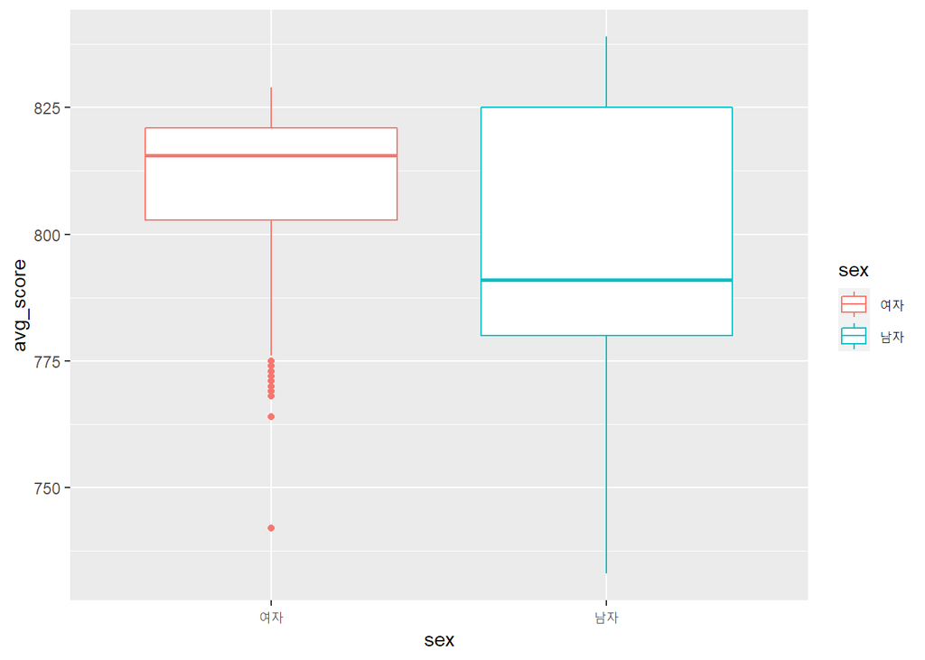

```r
sex_credit %>%
  ggplot(aes(x=sex, y=avg_score)) +
  geom_boxplot(aes(color=sex))
```

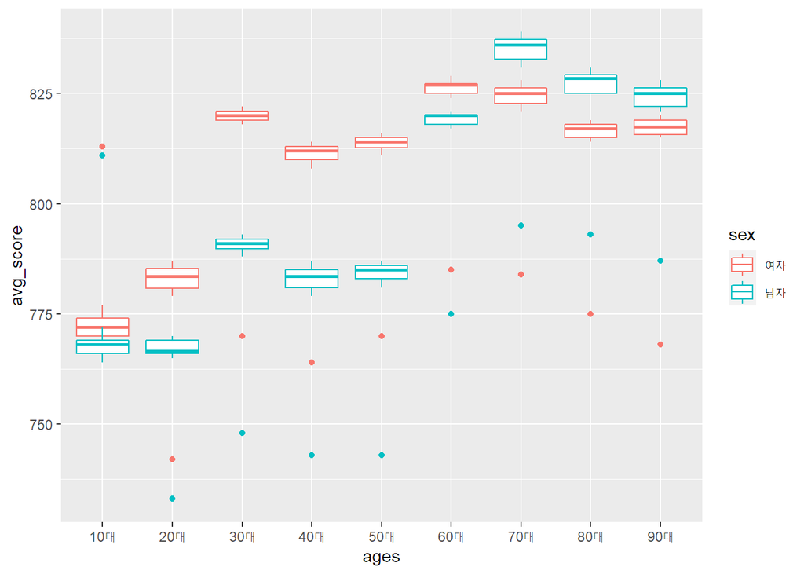

```r
sex_credit %>%
  ggplot(aes(x=ages, y=avg_score)) +
  geom_boxplot(aes(color=sex), position="identity")
```

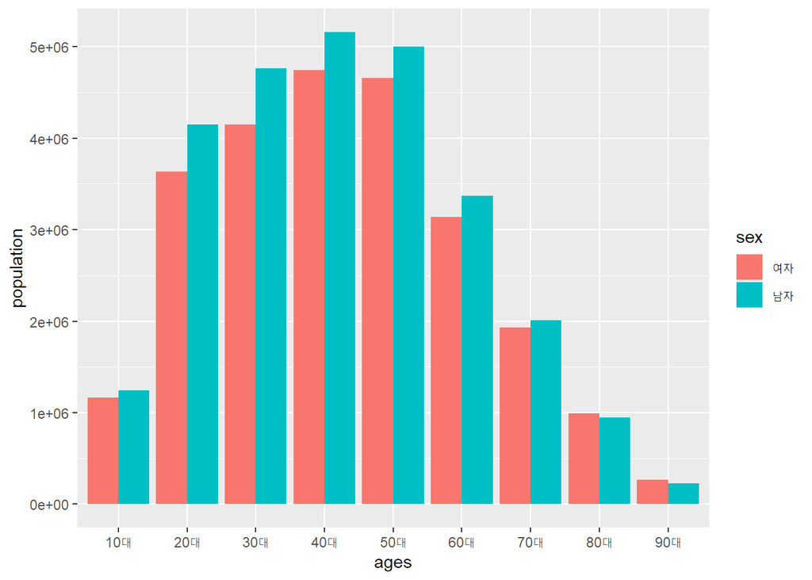

```r
sex_credit %>%
  ggplot(aes(x=ages, y=population)) +
  geom_bar(aes(fill=sex), stat="identity", position="dodge")
```

3. num_usecard(카드사용개수),num_opencard(카드개설개수)

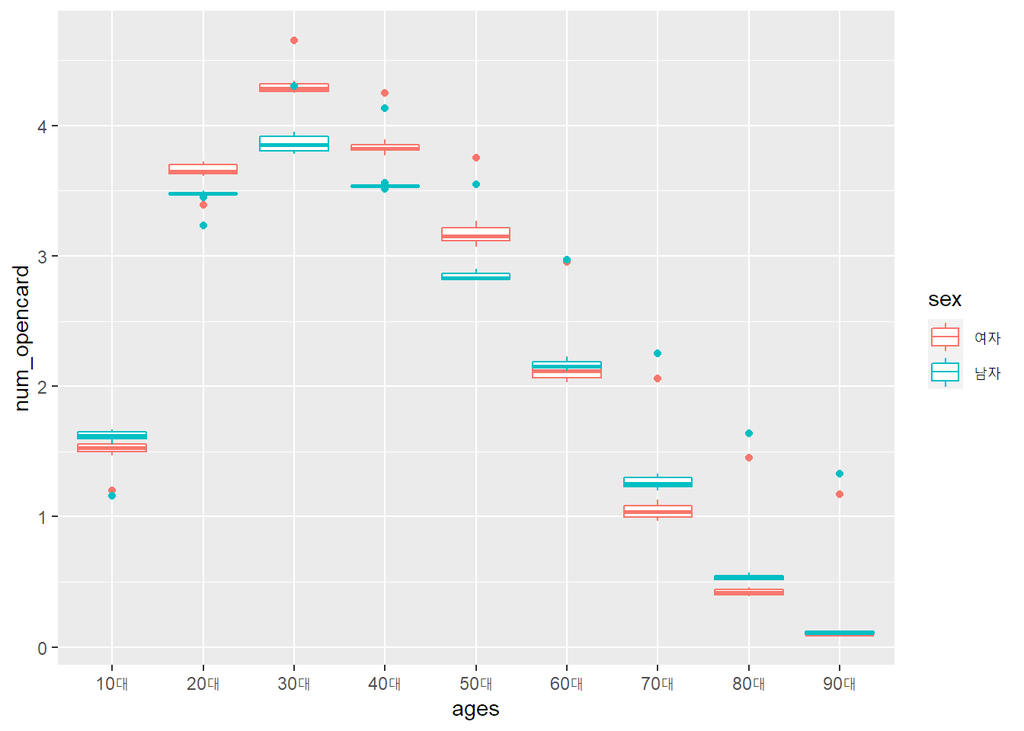

```r
sex_credit %>%
  ggplot(aes(x=ages, y=num_opencard)) +
  geom_boxplot(aes(color=sex), position="identity")
```

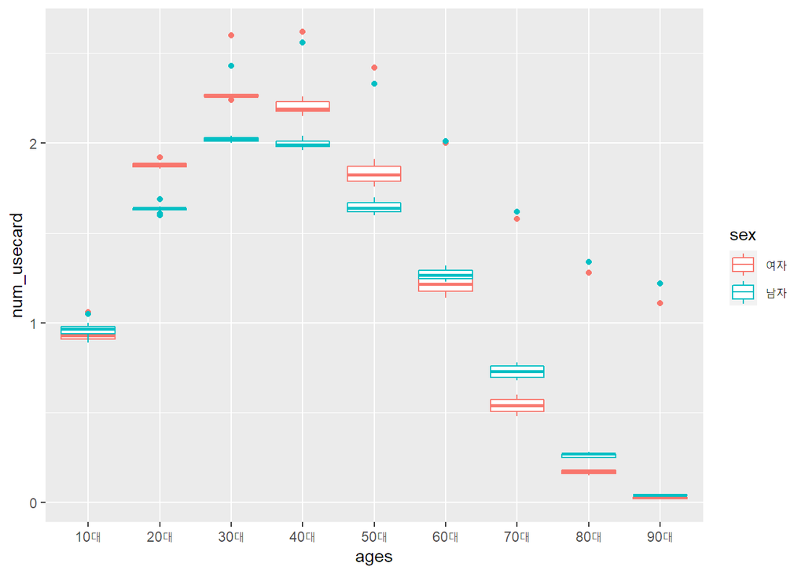

```r
sex_credit %>%
  ggplot(aes(x=ages, y=num_usecard)) +
  geom_boxplot(aes(color=sex), position="identity")
```

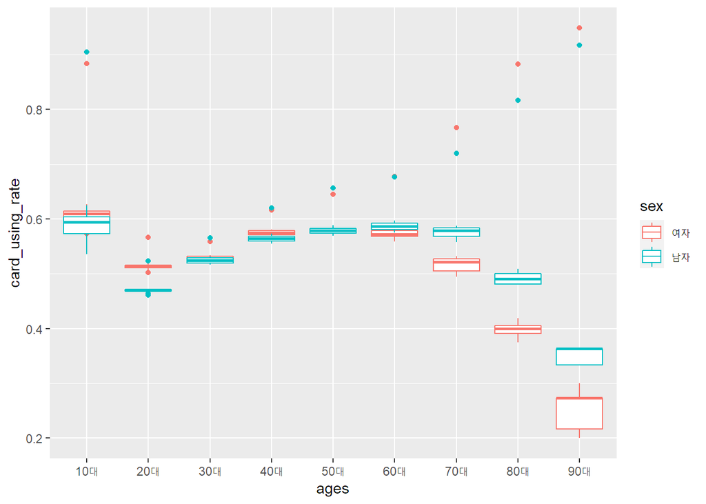

```r
sex_credit %>%
  mutate(card_using_rate = num_usecard/num_opencard) %>%
  ggplot(aes(x=ages, y=card_using_rate)) +
  geom_boxplot(aes(color=sex), position="identity")
```

4. 월카드 소비액(monthly_card_spend)

=> 월카드 소비액은 30대~60대의 경우 남성이 더욱 많이 쓴다. => 하지만 20대의 경우 여성이 더 많은 소비를 함을 보인다.

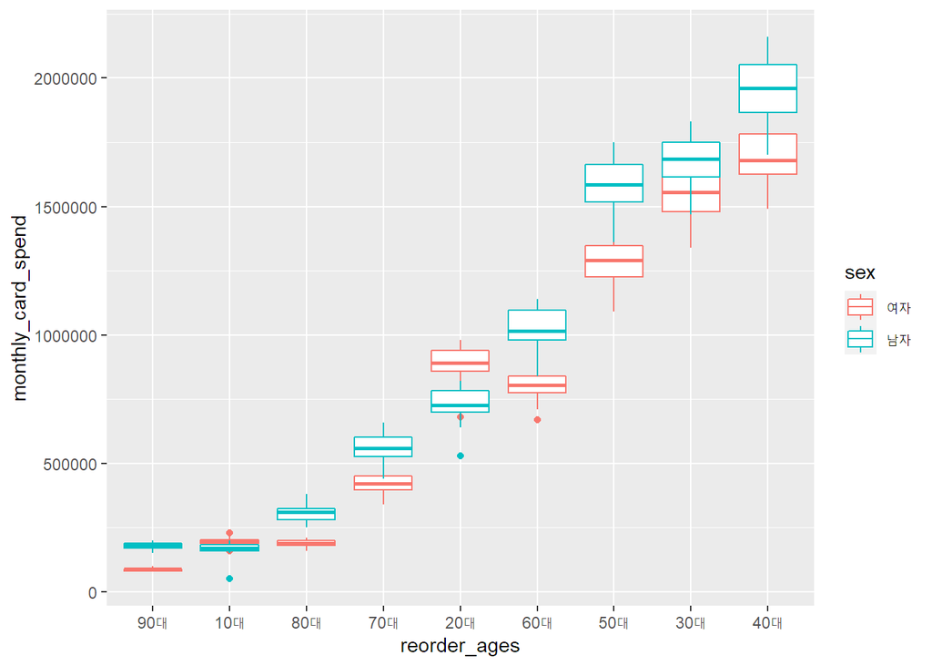

```r
sex_credit %>%
  mutate(reorder_ages = factor(sex_credit$ages, levels=levels(reorder(sex_credit$ages, sex_credit$monthly_card_spend, median, na.rim=TRUE)))) %>%
  ggplot(aes(x=reorder_ages, y=monthly_card_spend)) +
  geom_boxplot(aes(color=sex), position="identity")
```

5. 대출금액과 각 대출종류에 대한 비율
- monthly_lc: 대출약정금액으로 대출총액과의 차이는 아직 대출금을 받지 않은 경우 -> 이변수는 주관적으로 보았을 때 의미가 없다고 생각
- 월별 loan, bk_loan순으로 많으며 보통 남성이 더 많은 대출을 가지고 있다.

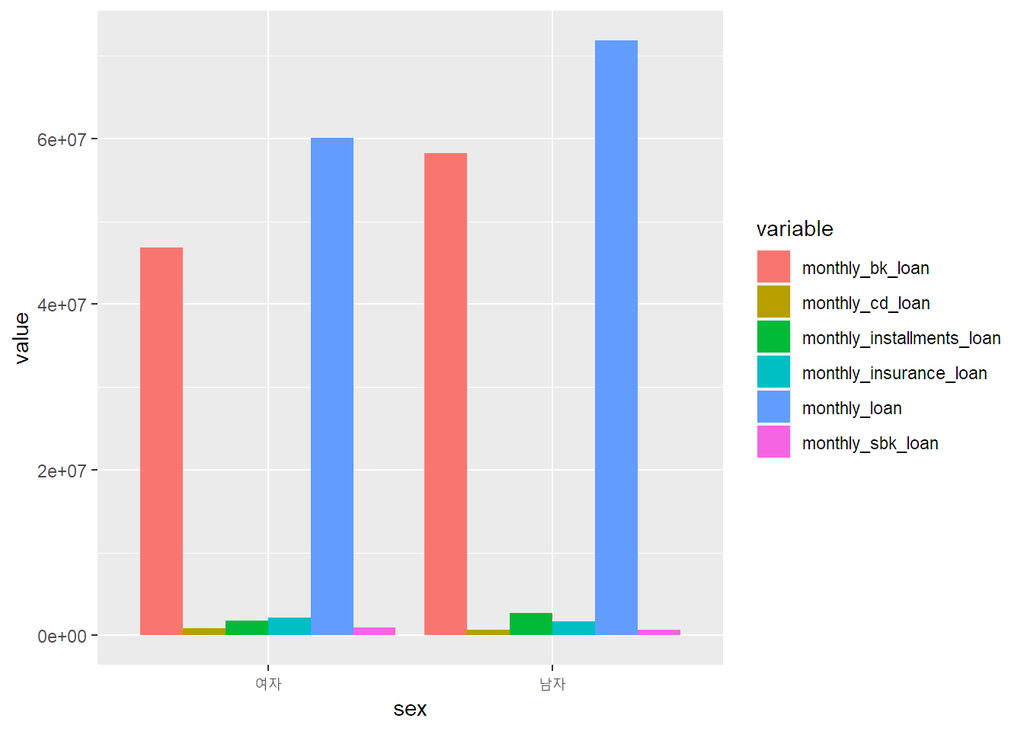

```r
sex_credit %>%
  group_by(sex) %>%
  summarise( monthly_loan = mean(monthly_loan),
             monthly_bk_loan = mean(monthly_bk_loan),
             monthly_cd_loan = mean(monthly_cd_loan),
             monthly_installments_loan = mean(monthly_installments_loan),
             monthly_insurance_loan = mean(monthly_insurance_loan),
             monthly_sbk_loan = mean(monthly_sbk_loan)) %>%
   pivot_longer("monthly_loan":"monthly_sbk_loan",
               values_to = "value", names_to = "variable") %>%
  ggplot() +
  geom_bar(aes(x=sex, y=value, fill=variable), position="dodge", stat="identity")
```

- 이를 제외하고는

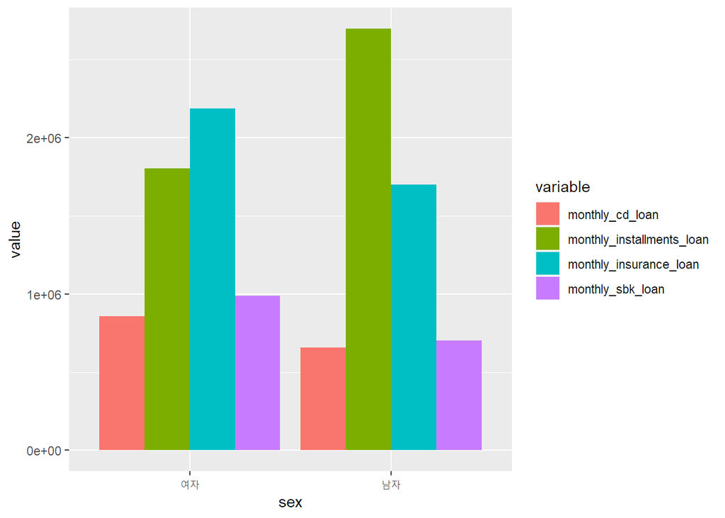

```r
sex_credit %>%
  group_by(sex) %>%
  summarise( monthly_cd_loan = mean(monthly_cd_loan),
             monthly_installments_loan = mean(monthly_installments_loan),
             monthly_insurance_loan = mean(monthly_insurance_loan),
             monthly_sbk_loan = mean(monthly_sbk_loan)) %>%
   pivot_longer("monthly_cd_loan":"monthly_sbk_loan",
               values_to = "value", names_to = "variable") %>%
  ggplot() +
  geom_bar(aes(x=sex, y=value, fill=variable), position="dodge", stat="identity")
```

6. 남은 잔액

loan_commitment : 한도 대출 금액(마이너스 통장) inst_rep_loanb : 분할 상환 대출 금액 ls_rep_loanb : 일시 상환 대출 금액 credit_loan : 카드 대출 금액 mortgage_loan : 담보 대출 금액

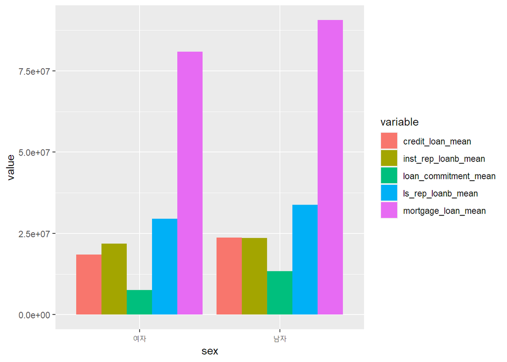

```r
sex_credit %>%
  mutate(all_loanb = inst_rep_loanb + ls_rep_loanb) %>%  #남은 총 대출잔액
  group_by(sex) %>%
  summarise(all_loanb_mean = mean(all_loanb),
            loan_commitment_mean = mean(loan_commitment),
            inst_rep_loanb_mean = mean(inst_rep_loanb),
            ls_rep_loanb_mean = mean(ls_rep_loanb),
            credit_loan_mean = mean(credit_loan),
            mortgage_loan_mean = mean(mortgage_loan)
            ) %>%
  pivot_longer("loan_commitment_mean":"mortgage_loan_mean",
               values_to = "value", names_to = "variable") %>%
  ggplot() +
  geom_bar(aes(x=sex, y=value, fill=variable), position="dodge", stat="identity")
```